# unitary-disentanglement-RG

A unitary transformation based renormalization group for correlated electronic systems.

To begin with in the work [arxiv:1802.06528](https://arxiv.org/abs/1802.06528) we present the unitary transformation($U$) that disentangles one electronic state from the every other electronic degree of freedom. This transformations when applied to a system of electrons described by a Hamiltonian block diagonalizes the Hamiltonian which is represented in the computational basis of occupied(1) and occupied(0) electronic states. The number operator and its eigenstates are represented as:

[figure not shown]

.  
Here $1_{1}$ corresponds to a state $1$ being occupied and $0_{1}$ to it being unoccupied and $\hat{n}$ is the number operator.

This dis-entangling transformations when carried out iteratively for electronic states starting from the highest single particle energies down to the lowest, comprises a renormalization group framework. A typical work flow for this method is presented below,

[figure not shown]

**Fig.1** - Schematic diagram of the RG procedure. The feedback loop shows the replacement of $H\to H'$ and $1\to 2$. $H'$ and $U_{2}$ satisfy the condition shown in the middle block, thereby generating the Hamiltonian for the next step. At each step, a commuting operator $\hat{n}_{1}$ is generated via the many-body rotation, such that its eigenvalues are the good quantum nos.

Let us give a visual feel for what the middle block does: Any general electronic Hamiltonian $H$ comrpising of N electronic states has a $2^{N}\times 2^{N}$ matrix representation in the occupation number space(i.e 2 confs. for each electronic state $\therefore$ $2^{N}$ such confs. for N of them). In the occupied(1) and unoccupied(0) basis states the Hamiltonian can be represented as a combination of 4 $2^{N-1}\times 2^{N-1}$ blocks,

[figure not shown]

The Unitary($U$) transformation renders this matrix block diagonal:

[figure not shown]

Succesive application of unitary transformations lays bare a inherent quantum energy scale($\omega$) (arising out of the off-diagonal blocks of the Hamiltonian) that tracks the newer Hamiltonian blocks from low to high energies:

[figure not shown]

We applied this technique to the simplest universal model for strongly interacting electronic systems:- the 2d Hubbard model on a square lattice,

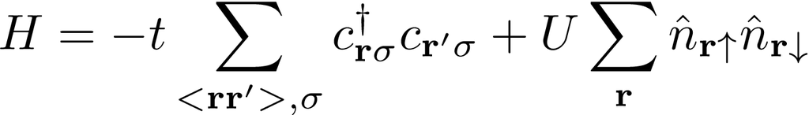

The first term represents electrons on hopping on a 2d square lattice (where each position is marked by $\hat{r}=x\hat{i}+y\hat{j}$) between nearest neighbours, while the second term represents a highly screened repulsive electronic interaction(i.e. onsite interaction).

This problem has been extensively studied by sophisticated techniques like Cluster Dynamical Mean Field Theory, Density matrix renormalizatio group, Density Matrix Embedding Theory, Quantum Monte Carlo (to name a few) [LeBlanc.et.al](https://journals.aps.org/prx/abstract/10.1103/PhysRevX.5.041041) and therefore remains a favorable playground for benchmarking new techniques against already established methods. We in our arxiv work [arxiv:1802.06528](https://arxiv.org/abs/1802.06528) have thoroughly benchmarked ground state energy values at half filling (no. of occ. states $=$ no. of unocc. states) and with hole doping i.e. (no. of occ. states $<$ no. of unocc. states).

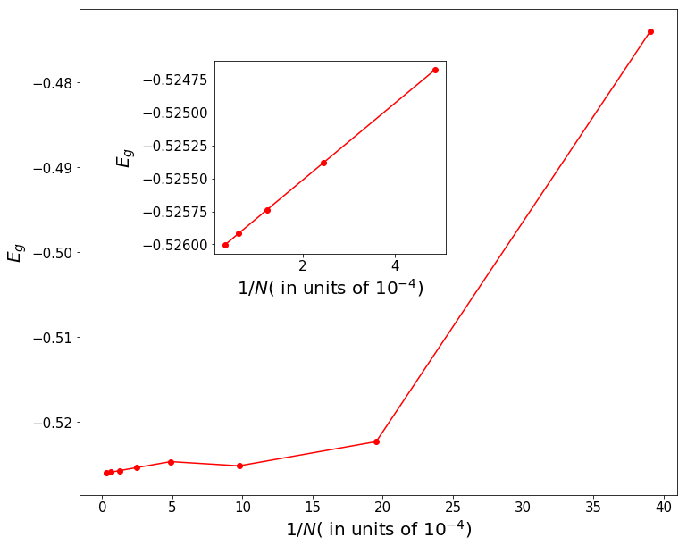

**Fig.2.** Finite-size scaling of the saturation value for $E_{g}\equiv E_{gs}$ with $1/\sqrt{\text{Volume}}$ with increasing $k$-space grid size from $2^{8}\times 2^{8}$ to $2^{15}\times 2^{15}$. The saturation $E_{gs}$ for the largest grid is observed to be $-0.526$(for $t=1$). The error bar for all data points is $\sim \text{O}(10^{-}4t)$. Inset: Zoomed view of finite-size scaling plot for lattice sizes $2^{11}\times 2^{11}$ to $2^{15}\times 2^{15}$.

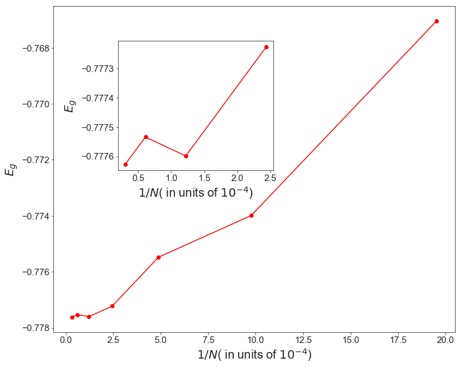

The benchmarking codes at half filling and at 0.125 doping for $U_{0}=8$ has been made available in Github.

[__Benchmarking2DHubbard__](https://github.com/xp7orer/xp7orer.github.io/tree/master/unitary-disentanglement-RG/benchmarking2DHubbard)

We have also done further benchmarking exercises for different values of $U_{0}$ at half filling and $12.5\%$ doping, the table is presented in [arxiv:1802.06528](https://arxiv.org/abs/1802.06528).

Given the satisfactory benchmarking results for the ground state energy density against existing numerical results we used the associated ground state many body wavefunction to track the change in nature of Mott liquid with doping. We demonstrate the collapse of the pseudogap for charge excitations (Mottness) at a quantum critical doping point(25$\%$ doping for $U_{0}=8$) possessing a nodal non-Fermi liquid with superconducting fluctuations, and spin-pseudogapping near the antinodes. d-wave Superconducting order is shown to arise from this quantum critical state of matter.